# Sample Script

Parameter Estimation Demo

Marie Bouffard

2022-05-23

The following sample code comes from part of an assignment I completed for my Advanced Environmental Data Analysis course at the Bren School of Environmental Science and Management on 3/4/2021.

### Initial Parameter estimates

**a.)** Exploratory plot of wild catch over time.

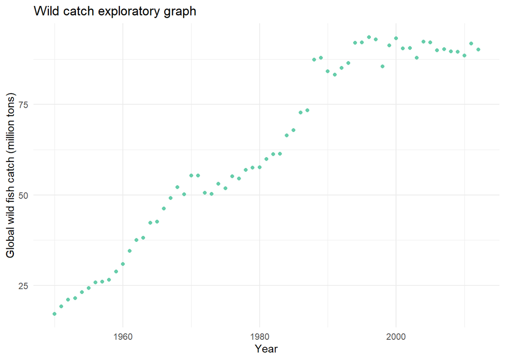

```r
# Exploratory plot

ggplot(data = catch_year, aes(x = year, y = wild_catch)) +
  geom_point(color = "aquamarine3") +
  labs(
    title = "Wild catch exploratory graph",
    x = "Year",
    y = "Global wild fish catch (million tons)"
  ) +
  theme_minimal()
```

**b.)** This trend looks like it is following logistic growth where $K$ is about 90 million tons and $P_o$ appears to be around 17 million tons.

We can estimate $A$ at about 4.3 million tons using the equation $A=\frac{K-P_o}{P_o}$

We can estimate the growth rate constant during the exponential phase by fitting a linear model and using the slope to estimate $k$.

```r
# filter for exponential section betweetn 1950 and 1990
wild_catch_exp <- catch_year %>%
  select(start_year, wild_catch) %>%
  filter(start_year < 40) %>%
  mutate(ln_catch = log(wild_catch))

# Linear model
lm_k <- lm(ln_catch ~ start_year, data = wild_catch_exp)
lm_k
```

```
##
## Call:
## lm(formula = ln_catch ~ start_year, data = wild_catch_exp)
##
## Coefficients:
## (Intercept)   start_year
##     3.07932      0.03562
```

This gives us our initial estimate for $k$, 0.035, along with our estimates for $K$ ~ 90 and $A$ ~ 4.3.

### Nonlinear Least Squares

```r
# Model info with estimated starting parameter values
wild_nls <- nls(wild_catch ~ K/(1 + A*exp(-r*start_year)),
              data = catch_year,
              start = list(K = 90, A = 4.3, r = 0.035),
              trace = TRUE)
```

```
## 51040.12    (6.53e+00): par = (90 4.3 0.035)
## 49768.55    (5.96e+00): par = (60.49203 2.479191 0.05051047)
## 11954.72    (2.78e+00): par = (78.8736 3.496565 0.06754032)
## 1370.502    (6.28e-02): par = (100.4536 4.384618 0.06968184)
## 1365.150    (2.49e-03): par = (100.2358 4.318639 0.06996247)
## 1365.143    (3.96e-04): par = (100.2849 4.31596 0.0698747)
## 1365.143    (6.32e-05): par = (100.2774 4.316387 0.06988872)
## 1365.143    (1.01e-05): par = (100.2786 4.31632 0.06988648)
## 1365.143    (1.61e-06): par = (100.2784 4.31633 0.06988684)
```

```r
summary(wild_nls)
```

```
##
## Formula: wild_catch ~ K/(1 + A * exp(-r * start_year))
##
## Parameters:
##    Estimate Std. Error t value Pr(>|t|)
## K 1.003e+02  2.734e+00   36.68   <2e-16 ***
## A 4.316e+00  2.929e-01   14.73   <2e-16 ***
## r 6.989e-02  4.648e-03   15.04   <2e-16 ***
## ---
## Signif. codes:  0 '***' 0.001 '**' 0.01 '*' 0.05 '.' 0.1 ' ' 1
##
## Residual standard error: 4.77 on 60 degrees of freedom
##
## Number of iterations to convergence: 8
## Achieved convergence tolerance: 1.611e-06
```

**c.)** Parameter outcomes

```r
wild_out_tidy <- broom::tidy(wild_nls)

wild_out_tidy
```

```
## # A tibble: 3 x 5
##   term  estimate std.error statistic  p.value
##   <chr>    <dbl>     <dbl>     <dbl>    <dbl>
## 1 K     100.       2.73         36.7 8.57e-43
## 2 A       4.32     0.293        14.7 1.34e-21
## 3 r       0.0699   0.00465      15.0 5.14e-22
```

**d.)** Visualization of original data and model output

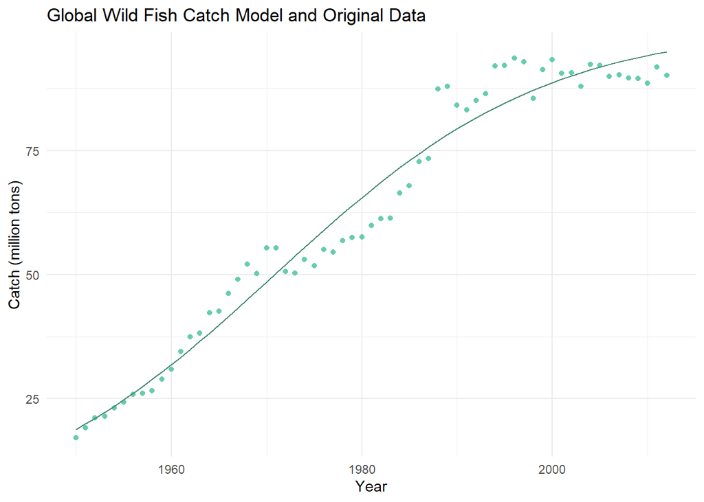

```r
# catch predictions
catch_predict <- predict(wild_nls)

# combine predictions and original data
wild_complete <- data.frame(catch_year, catch_predict)

# Plot together
ggplot(data = wild_complete, aes(x = year, y = wild_catch)) +
  geom_point(color = "aquamarine3") +
  geom_line(aes(x = year, y = catch_predict), color = "aquamarine4") +
    labs(
    title = "Global Wild Fish Catch Model and Original Data",
    x = "Year",
    y = "Catch (million tons)"
  ) +
  theme_minimal()
```